# IE 582 Homework 2

Burak Tabak (2019702177)

November 29, 2020

# Introduction

In this report, the codes and results is summarised for the tasks in Homework 2.

Firstly, we get the train data for X,Y,Z axis measurements and bind them. After that, the data converted to long format with TimeID, Timestep, X , Y, Z and Class.

Also, Velocity is calculated from acceleration by cumsum.

Below, you can find initial data.

```r
# Import libraries
library(data.table)
library(tidyverse)
library(lubridate)
library(kableExtra)
library(plotly)

train_data_path="/home/burak/Desktop/Lectures/IE582/HW2/Train"

# Read Data
X_Train = fread(list.files(train_data_path,full.names = T)[1])%>%mutate(axis="X",TimeId=row_number())
Y_Train = fread(list.files(train_data_path,full.names = T)[2])%>%mutate(axis="Y",TimeId=row_number())
Z_Train = fread(list.files(train_data_path,full.names = T)[3])%>%mutate(axis="Z",TimeId=row_number())
Train = rbind(X_Train,Y_Train,Z_Train)
colnames(Train) <- c("Class",paste0("Time",1:315),"Axis","TimeID")

# Convert to Long Format
Train = Train %>% select(TimeID,Class,Axis,everything())
Train_Final = melt(Train,1:3)%>%transmute(TimeID,Class,Axis,TimeINDEX=as.numeric(gsub("Time","",variable,fixed=T)),value)%>%
  spread(Axis,value)%>%select(TimeID,TimeINDEX,X,Y,Z,Class)%>% mutate(VX = cumsum(X),VY = cumsum(Y),VZ = cumsum(Z))

head(Train_Final) %>%
kbl(caption = "Initial Data") %>%
  kable_classic(full_width = F, html_font = "Cambria")
```

Initial Data

| TimeID | TimeINDEX | X | Y | Z | Class | VX | VY | VZ |
| --- | --- | --- | --- | --- | --- | --- | --- | --- |
| 1 | 1 | -0.3042432 | -2.119396 | -1.528965 | 6 | -0.3042432 | -2.119396 | -1.528965 |
| 1 | 2 | -0.3042432 | -2.119396 | -1.528965 | 6 | -0.6084864 | -4.238792 | -3.057930 |
| 1 | 3 | -0.3042432 | -2.119396 | -1.528965 | 6 | -0.9127296 | -6.358187 | -4.586895 |
| 1 | 4 | -0.3042432 | -2.119396 | -1.528965 | 6 | -1.2169728 | -8.477583 | -6.115860 |
| 1 | 5 | -0.3042432 | -2.119396 | -1.528965 | 6 | -1.5212160 | -10.596979 | -7.644825 |
| 1 | 6 | -0.3042432 | -2.119396 | -1.528965 | 6 | -1.8254593 | -12.716375 | -9.173791 |

## Task - a

Now, in this part; we will plot velocity for each class and try to figure out the relation between gesture figures.

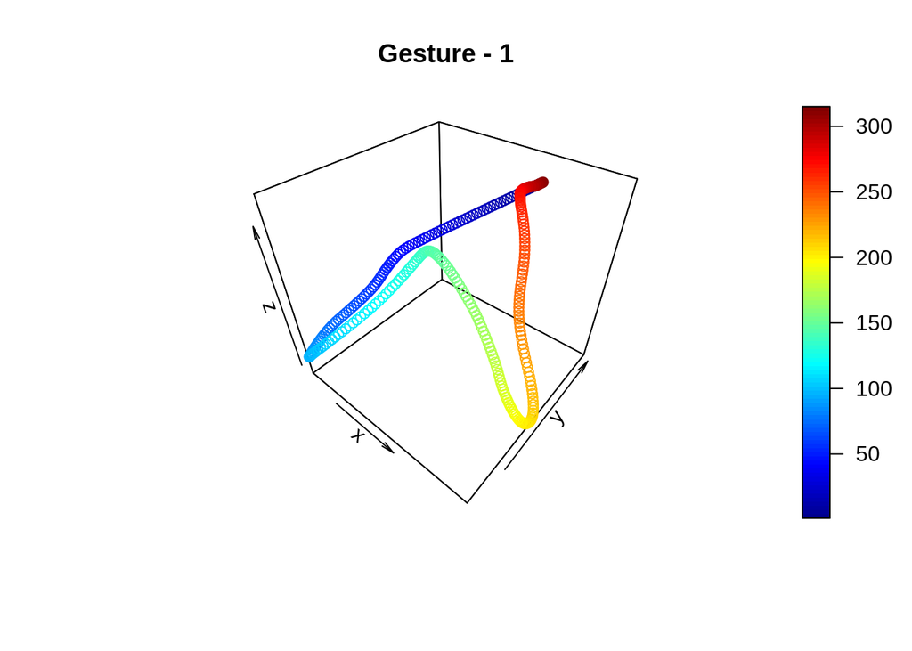

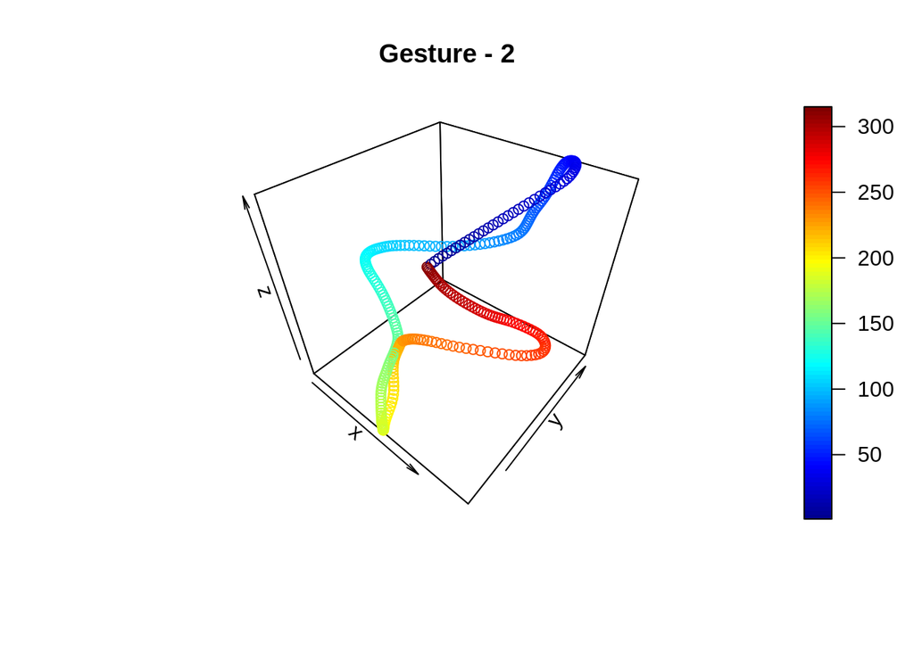

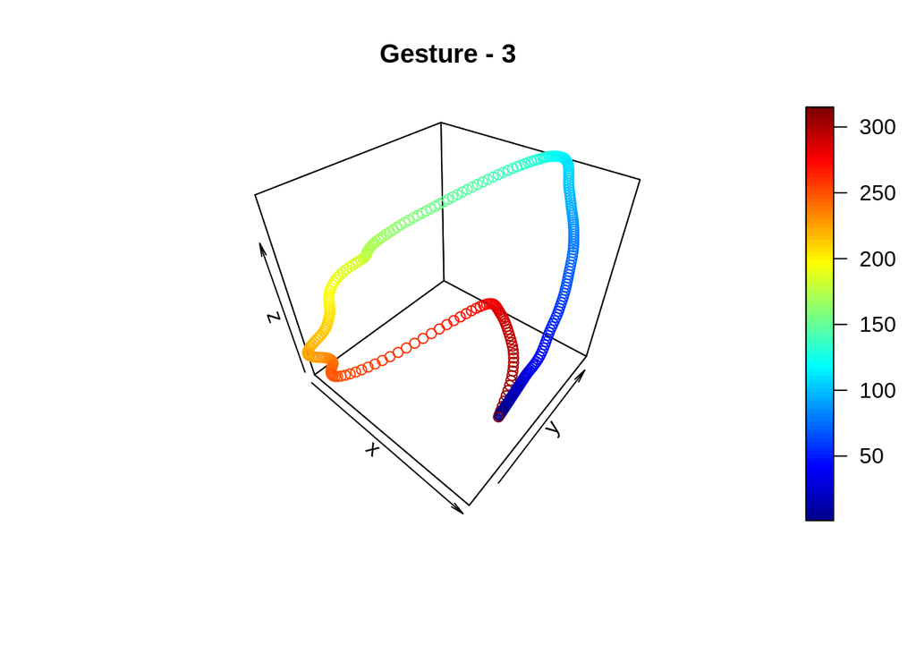

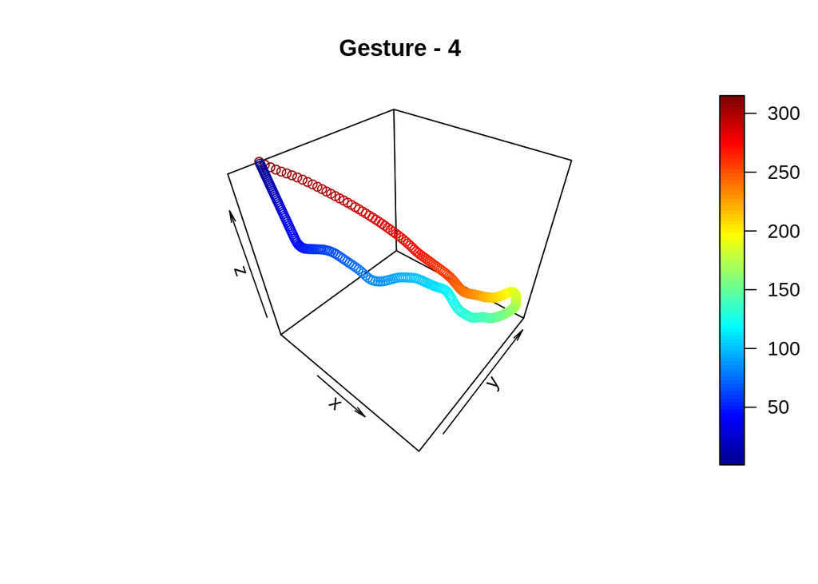

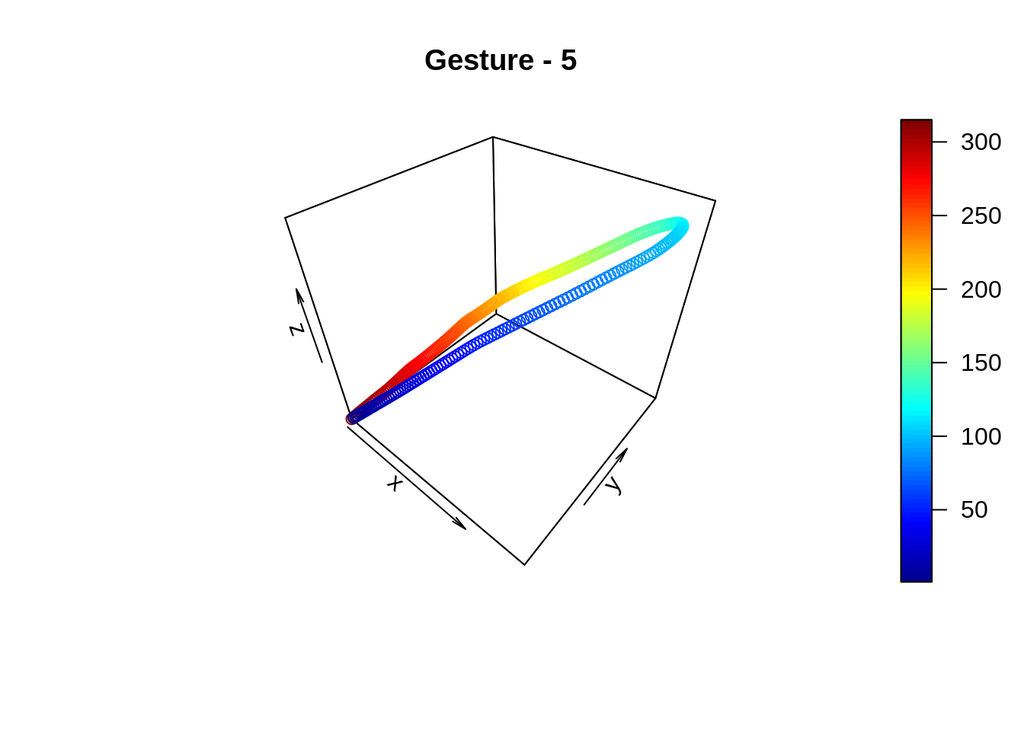

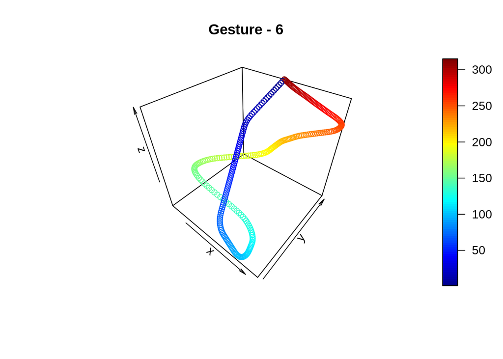

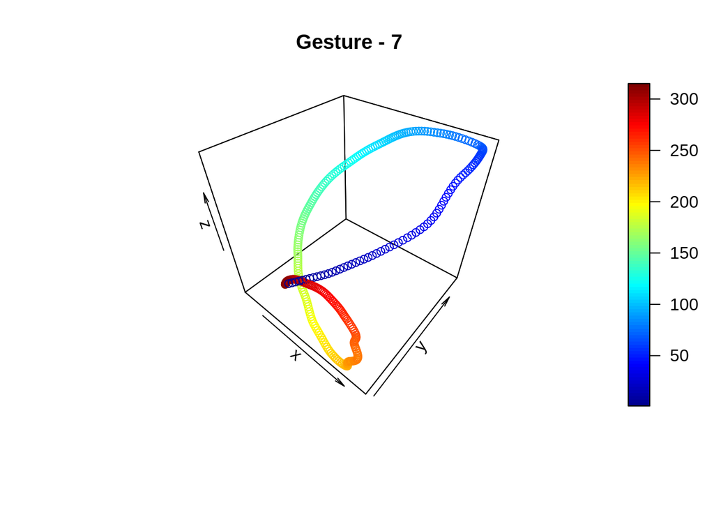

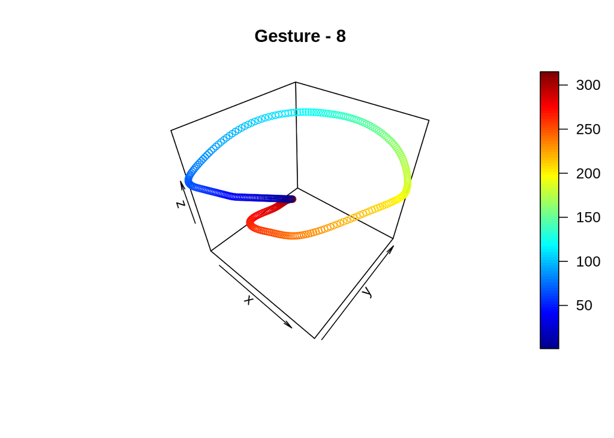

```r
# Get one example for each class.
Train_Plot = Train_Final %>%group_by(Class,TimeINDEX)%>%
  mutate(rn=row_number())%>%ungroup()%>%filter(rn==1)%>%select(-rn)

for(class in 1:8){
  data=Train_Plot%>%filter(Class==class)
  title_name=paste0("Gesture - ",class)
  plot3D::scatter3D(x=data$VX, y = data$VY, z = data$VZ,colvar = data$TimeINDEX,main=title_name)
}
```

## Task - b

In this part, we will transform 3D X,Y,Z feature set to 1D feature by applying Principal Component Analysis.

Now, apply PCA to scaled data and bind Principal Components to original data.

```r
pca_all = princomp(Train_Final%>%select(X,Y,Z),cor=T)
summary(pca_all)
```

```
## Importance of components:
##                          Comp.1    Comp.2    Comp.3
## Standard deviation     1.213171 1.0198583 0.6986445
## Proportion of Variance 0.490595 0.3467037 0.1627014
## Cumulative Proportion  0.490595 0.8372986 1.0000000
```

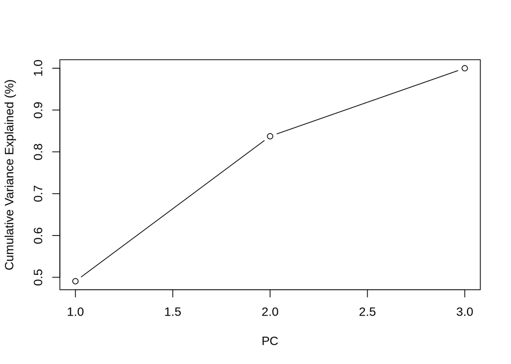

```r
var_exp=(pca_all$sdev^2)/sum(pca_all$sdev^2)
plot(cumsum(var_exp), xlab = "PC",ylab = "Cumulative Variance Explained (%)", type = "b")
```

From the results, we can observe that almost half of the total variance is explanied by first principal component. With first two, we cover %80 of total variance.

Now, derive Principal Component scores.

```r
Train_Scored = cbind(Train_Final,pca_all$scores)
head(Train_Scored) %>%
kbl(caption = "Data with Principal Components") %>%
  kable_classic(full_width = F, html_font = "Cambria")
```

Data with Principal Components

| TimeID | TimeINDEX | X | Y | Z | Class | VX | VY | VZ | Comp.1 | Comp.2 | Comp.3 |
| --- | --- | --- | --- | --- | --- | --- | --- | --- | --- | --- | --- |
| 1 | 1 | -0.3042432 | -2.119396 | -1.528965 | 6 | -0.3042432 | -2.119396 | -1.528965 | -2.496541 | 0.6919923 | 0.4823007 |
| 1 | 2 | -0.3042432 | -2.119396 | -1.528965 | 6 | -0.6084864 | -4.238792 | -3.057930 | -2.496541 | 0.6919923 | 0.4823007 |
| 1 | 3 | -0.3042432 | -2.119396 | -1.528965 | 6 | -0.9127296 | -6.358187 | -4.586895 | -2.496541 | 0.6919923 | 0.4823007 |
| 1 | 4 | -0.3042432 | -2.119396 | -1.528965 | 6 | -1.2169728 | -8.477583 | -6.115860 | -2.496541 | 0.6919923 | 0.4823007 |
| 1 | 5 | -0.3042432 | -2.119396 | -1.528965 | 6 | -1.5212160 | -10.596979 | -7.644825 | -2.496541 | 0.6919923 | 0.4823007 |
| 1 | 6 | -0.3042432 | -2.119396 | -1.528965 | 6 | -1.8254593 | -12.716375 | -9.173791 | -2.496541 | 0.6919923 | 0.4823007 |

After that, plot first principal component values for each class to check whether classes can be differentiable by shape.

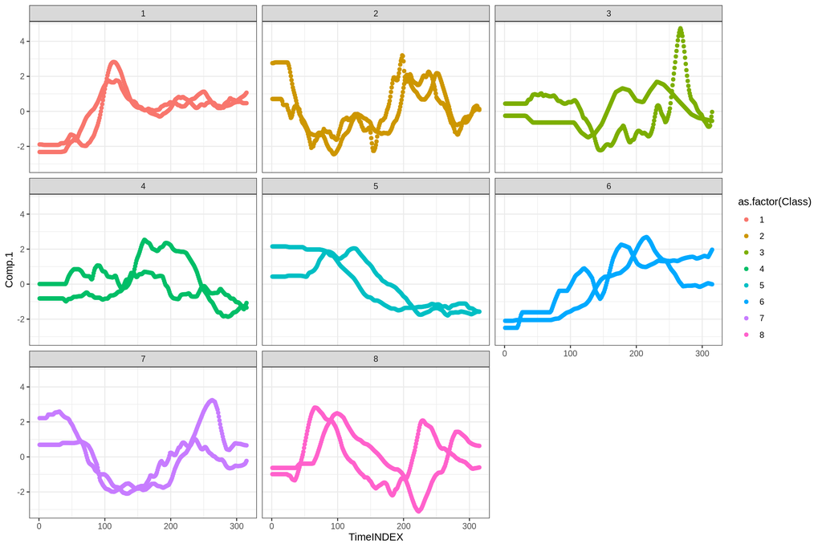

```r
# Get two example for each class.
Train_PC1 = Train_Scored %>%group_by(Class,TimeINDEX)%>%
  mutate(rn=row_number())%>%ungroup()%>%filter(rn<=2)%>%select(-rn)

ggplot(Train_PC1)+geom_point(aes(x=TimeINDEX,y=Comp.1,col=as.factor(Class)))+facet_wrap(~Class)+theme_bw()
```

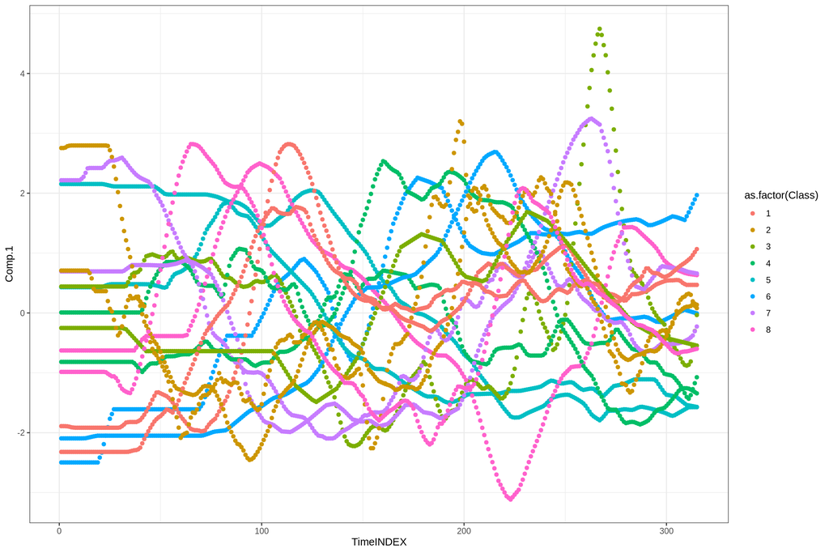

```r
ggplot(Train_PC1)+geom_point(aes(x=TimeINDEX,y=Comp.1,col=as.factor(Class)))+theme_bw()
```

We can observe that;

- Time series of first PC are similar within classes especially for 1,2,5,6,7
- The series for different classes looks different.
- Although similarity can be seen, there are differences because total variance explained by first principal component is the half of total variance.

## Task - c

In this part, we will apply PCA for each gesture and compare results with b part.

```
## [1] "Gesture 1"
## Importance of components:
##                           Comp.1    Comp.2    Comp.3
## Standard deviation     1.1779640 0.9845807 0.8018738
## Proportion of Variance 0.4625331 0.3231331 0.2143339
## Cumulative Proportion  0.4625331 0.7856661 1.0000000
```

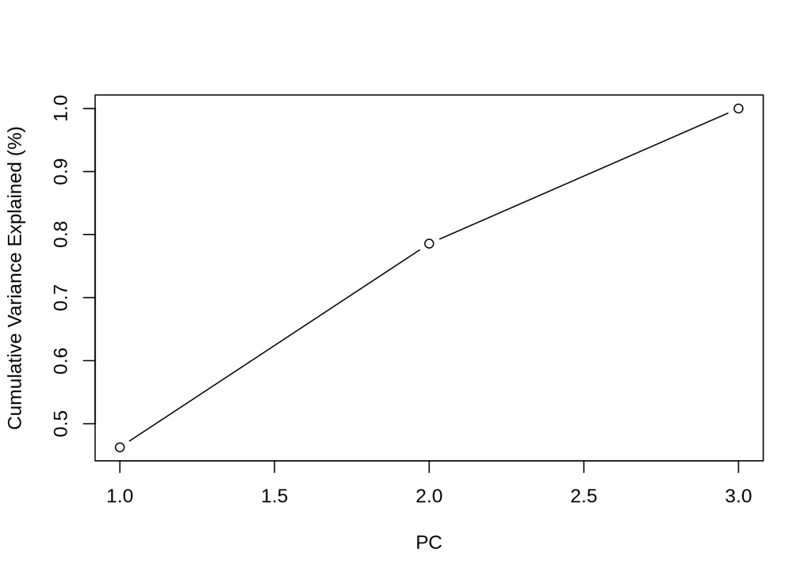

```
## [1] "Gesture 2"
## Importance of components:
##                           Comp.1    Comp.2    Comp.3
## Standard deviation     1.2400176 0.9682706 0.7244366
## Proportion of Variance 0.5125479 0.3125160 0.1749361
## Cumulative Proportion  0.5125479 0.8250639 1.0000000
```

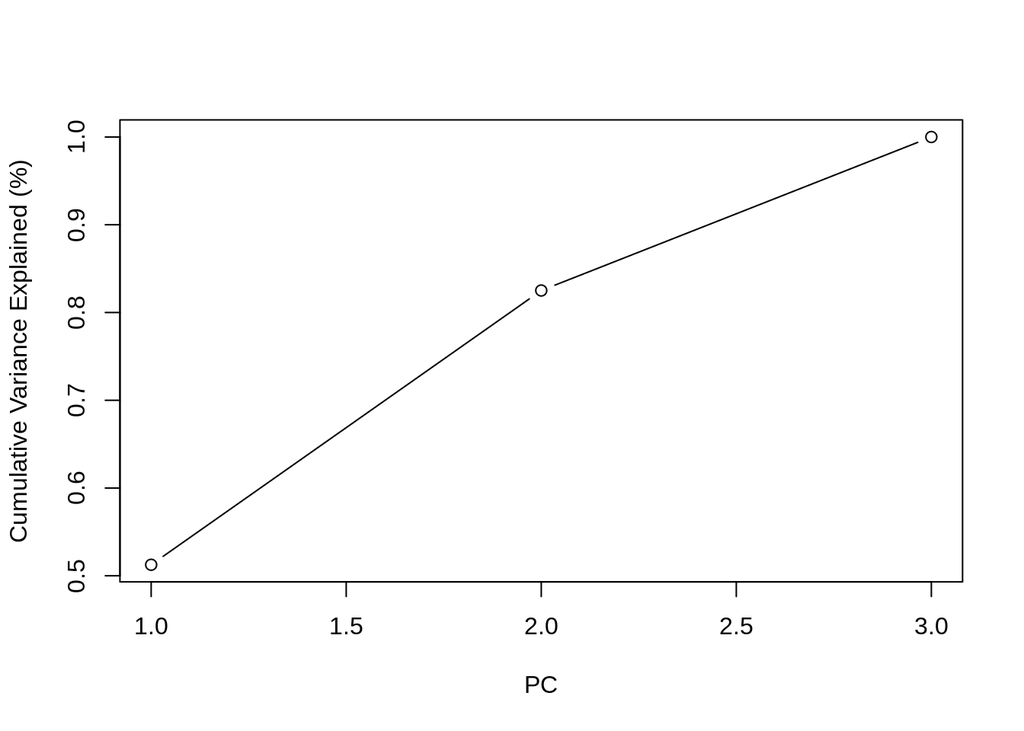

```
## [1] "Gesture 3"
## Importance of components:
##                          Comp.1    Comp.2    Comp.3
## Standard deviation     1.273669 0.9475424 0.6927707
## Proportion of Variance 0.540744 0.2992789 0.1599771
## Cumulative Proportion  0.540744 0.8400229 1.0000000
```

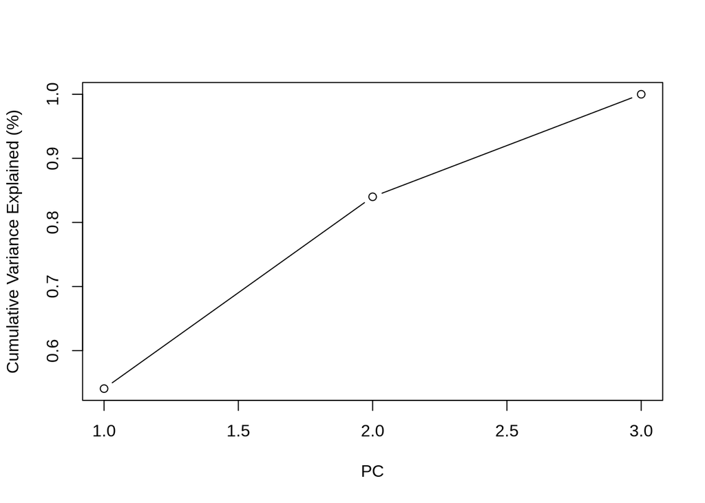

```
## [1] "Gesture 4"
## Importance of components:
##                           Comp.1    Comp.2    Comp.3
## Standard deviation     1.2846735 0.9605566 0.6534102
## Proportion of Variance 0.5501287 0.3075563 0.1423150
## Cumulative Proportion  0.5501287 0.8576850 1.0000000
```

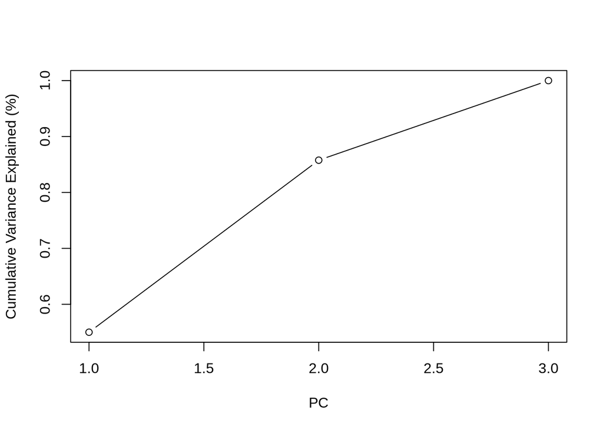

```
## [1] "Gesture 5"
## Importance of components:
##                           Comp.1    Comp.2     Comp.3
## Standard deviation     1.3934383 0.9076507 0.48425204
## Proportion of Variance 0.6472234 0.2746099 0.07816668
## Cumulative Proportion  0.6472234 0.9218333 1.00000000
```

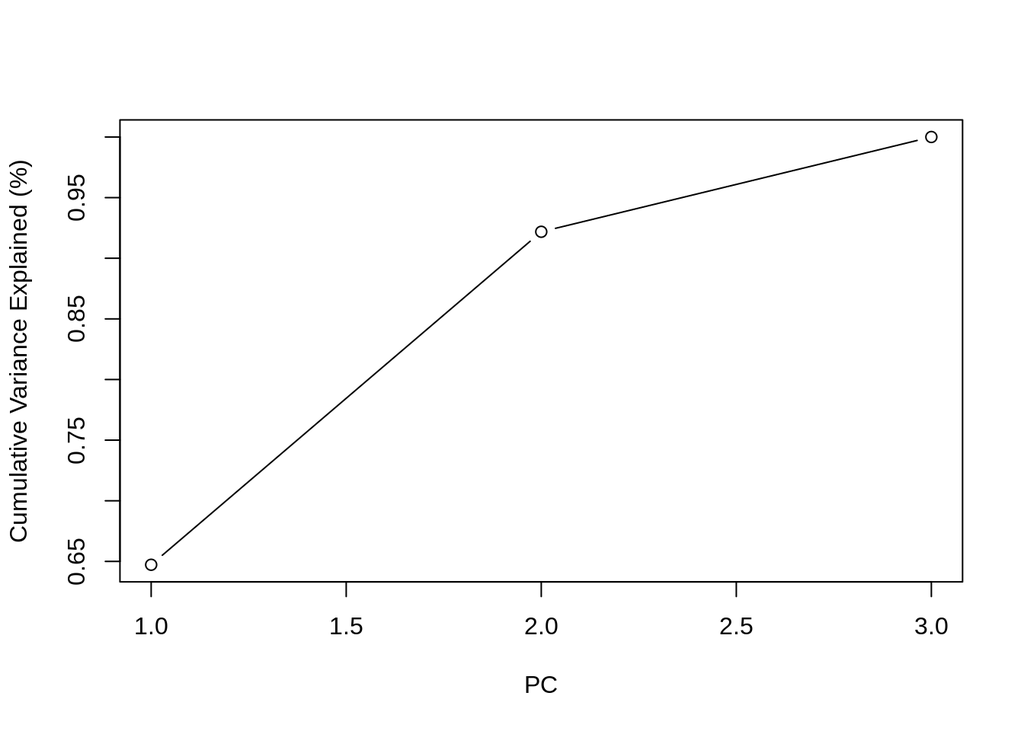

```
## [1] "Gesture 6"
## Importance of components:
##                           Comp.1    Comp.2     Comp.3
## Standard deviation     1.3097601 0.9941695 0.54420161
## Proportion of Variance 0.5718239 0.3294577 0.09871846
## Cumulative Proportion  0.5718239 0.9012815 1.00000000
```

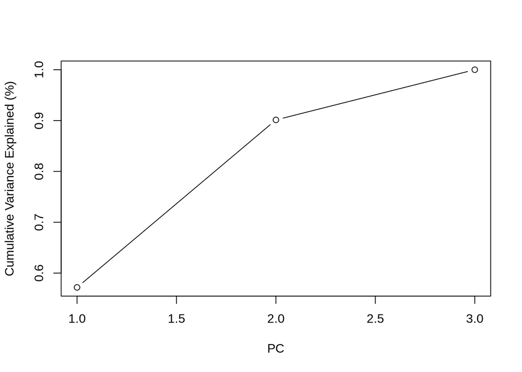

```
## [1] "Gesture 7"
## Importance of components:
##                           Comp.1    Comp.2    Comp.3
## Standard deviation     1.2480424 1.0144419 0.6428823
## Proportion of Variance 0.5192033 0.3430308 0.1377659
## Cumulative Proportion  0.5192033 0.8622341 1.0000000
```

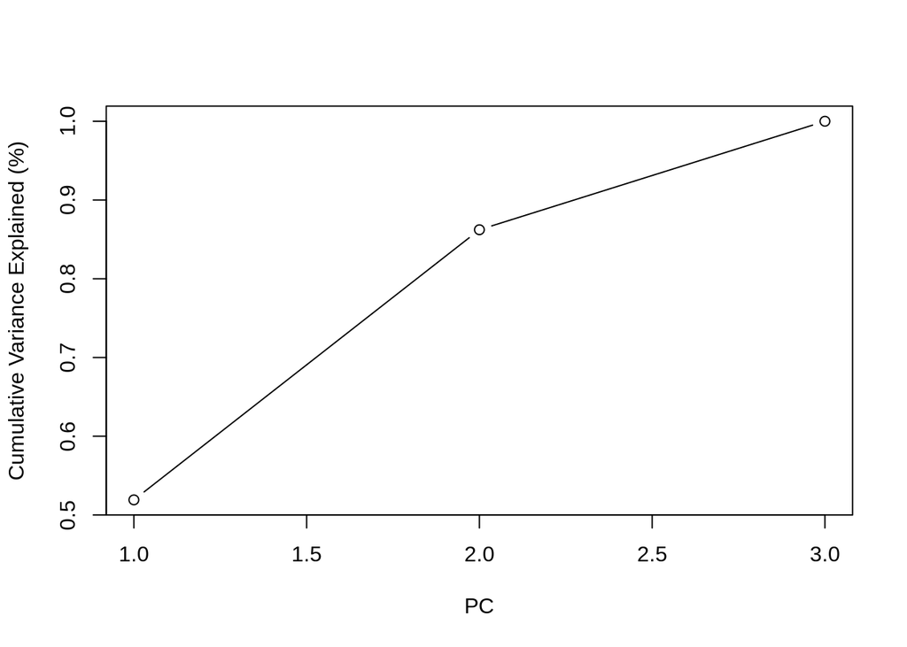

```
## [1] "Gesture 8"
## Importance of components:
##                           Comp.1    Comp.2     Comp.3
## Standard deviation     1.3565694 0.9675745 0.47277805
## Proportion of Variance 0.6134269 0.3120668 0.07450636
## Cumulative Proportion  0.6134269 0.9254936 1.00000000
```

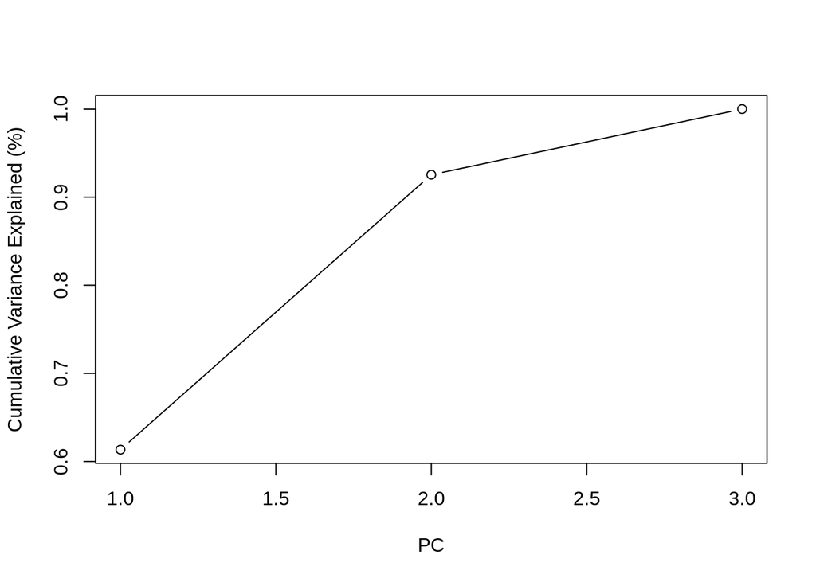

```r
Train_Scored_Sep = tibble()

for(gesture in 1:8){
  print(paste0("Gesture ",gesture))
  pca_temp = princomp(Train_Final%>%filter(Class==gesture)%>%select(X,Y,Z),cor=T)
  s=summary(pca_temp)
  print(s)
  var_exp=(pca_temp$sdev^2)/sum(pca_temp$sdev^2)
  plot(cumsum(var_exp), xlab = "PC",ylab = "Cumulative Variance Explained (%)", type = "b")
  Train_Scored_Sep = rbind(Train_Scored_Sep,cbind(Train_Final%>%filter(Class==gesture),pca_temp$scores))
}
```

```r
head(Train_Scored_Sep) %>%
kbl(caption = "Data with Principal Components for Each Gesture") %>%
  kable_classic(full_width = F, html_font = "Cambria")
```

Data with Principal Components for Each Gesture

| TimeID | TimeINDEX | X | Y | Z | Class | VX | VY | VZ | Comp.1 | Comp.2 | Comp.3 |
| --- | --- | --- | --- | --- | --- | --- | --- | --- | --- | --- | --- |
| 11 | 1 | -0.7914472 | -1.959984 | -0.2490781 | 1 | -0.7914482 | -1.959979 | -0.2490798 | -1.796413 | -0.4761548 | 1.0443027 |
| 11 | 2 | -0.7914472 | -1.959984 | -0.2490781 | 1 | -1.5828954 | -3.919962 | -0.4981579 | -1.796413 | -0.4761548 | 1.0443027 |
| 11 | 3 | -0.7958727 | -1.956600 | -0.2514390 | 1 | -2.3787681 | -5.876563 | -0.7495968 | -1.797139 | -0.4793054 | 1.0391774 |
| 11 | 4 | -0.8100650 | -1.945750 | -0.2590101 | 1 | -3.1888331 | -7.822313 | -1.0086069 | -1.799466 | -0.4894093 | 1.0227408 |
| 11 | 5 | -0.8492300 | -1.915809 | -0.2799033 | 1 | -4.0380631 | -9.738122 | -1.2885103 | -1.805888 | -0.5172917 | 0.9773825 |
| 11 | 6 | -0.9034648 | -1.874347 | -0.3088358 | 1 | -4.9415279 | -11.612469 | -1.5973461 | -1.814780 | -0.5559027 | 0.9145713 |

After that, plot first principal component values for each class to check whether classes can be differentiable by shape.

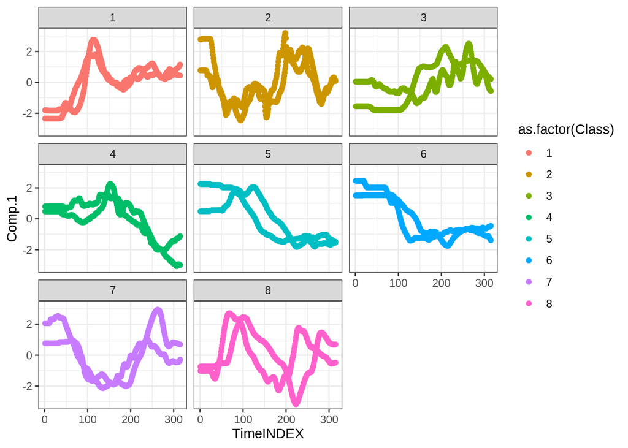

```r
# Get two example for each class.
Train_PC1_Sep = Train_Scored_Sep %>%group_by(Class,TimeINDEX)%>%
  mutate(rn=row_number())%>%ungroup()%>%filter(rn<=2)%>%select(-rn)

ggplot(Train_PC1_Sep)+geom_point(aes(x=TimeINDEX,y=Comp.1,col=as.factor(Class)))+facet_wrap(~Class)+theme_bw()
```

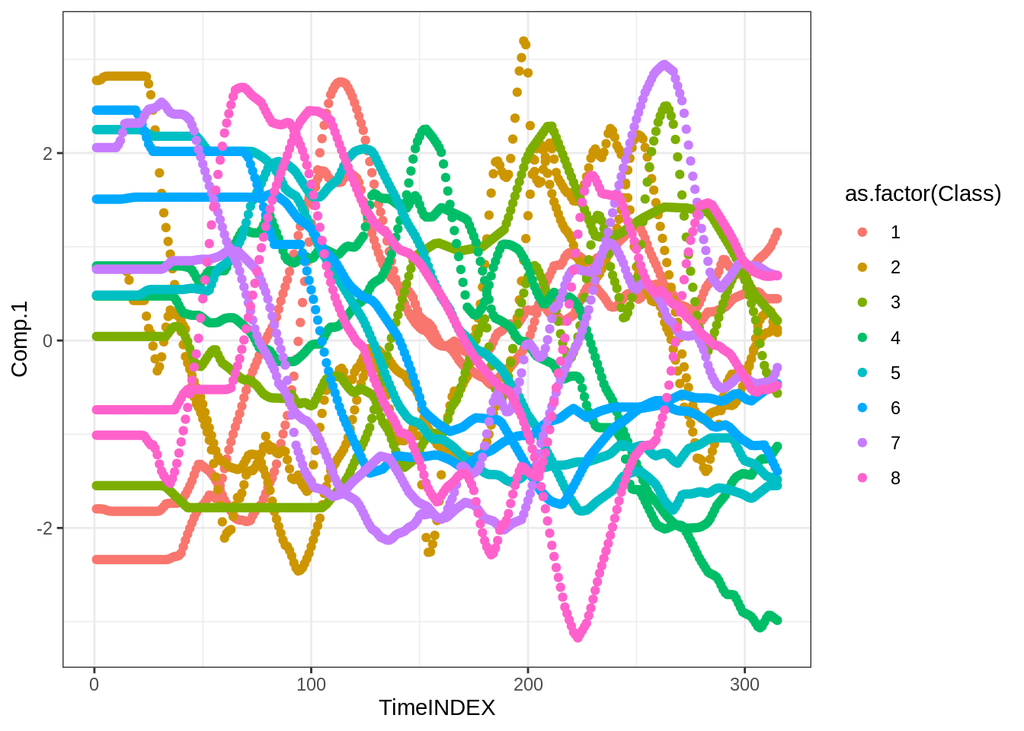

```r
ggplot(Train_PC1_Sep)+geom_point(aes(x=TimeINDEX,y=Comp.1,col=as.factor(Class)))+theme_bw()
```

From the above results, it can be seen that apart from Gesture 1, all other Gestures has first principal component with larger variance coverage. So, It seems reasonable to apply PCA to each gesture separately.

Also, it is clear that with larger variance coverage, the shape of time series from the same class is more similar compared to part b.

## Task - d

Now, we will find Euclidean Distance between each time series for each axis and then sum them up to obtain final distance measure.

```r
x_dist=dist(X_Train[,2:316],method = "euclidean",upper = T)
y_dist=dist(Y_Train[,2:316],method = "euclidean",upper = T)
z_dist=dist(Z_Train[,2:316],method = "euclidean",upper = T)
sum_dist = x_dist + y_dist + z_dist

### Summary of first 10
as.matrix(sum_dist)[1:10,1:10]
```

```
##           1        2        3        4        5        6        7        8
## 1   0.00000 87.68508 79.49081 86.40700 70.03667 82.72643 84.60599 57.85386
## 2  87.68508  0.00000 44.96116 63.11674 54.75039 63.15054 65.14662 86.15196
## 3  79.49081 44.96116  0.00000 74.07190 51.52769 60.07619 91.55259 76.05191
## 4  86.40700 63.11674 74.07190  0.00000 76.31456 66.35227 67.56241 96.09450
## 5  70.03667 54.75039 51.52769 76.31456  0.00000 63.14416 77.18365 58.13736
## 6  82.72643 63.15054 60.07619 66.35227 63.14416  0.00000 83.46017 81.73216
## 7  84.60599 65.14662 91.55259 67.56241 77.18365 83.46017  0.00000 78.76416
## 8  57.85386 86.15196 76.05191 96.09450 58.13736 81.73216 78.76416  0.00000
## 9  65.08497 60.93996 60.33332 85.50446 32.39985 73.14076 74.26561 47.65021
## 10 48.36508 99.70755 93.18018 75.28307 82.32799 88.25848 82.71620 61.75935
##           9       10
## 1  65.08497 48.36508
## 2  60.93996 99.70755
## 3  60.33332 93.18018
## 4  85.50446 75.28307
## 5  32.39985 82.32799
## 6  73.14076 88.25848
## 7  74.26561 82.71620
## 8  47.65021 61.75935
## 9   0.00000 75.66501
## 10 75.66501  0.00000
```

Now, we will apply multidimensional scaling to visualize time series in 2D by using dissimilarity measure.

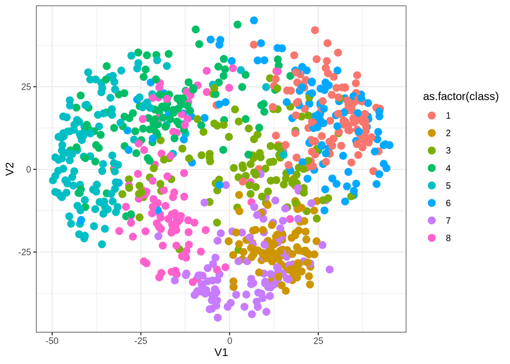

```r
md2 <- cmdscale(sum_dist, k=2, eig=T)

points2d = as.data.frame(md2$points)
points2d$class = X_Train$V1

ggplot(points2d)+geom_point(aes(x=V1,y=V2,col=as.factor(class)),size=3)+theme_bw()
```

We can observe that;

- Gestures with opposite directions such as 3-4, 5-6, 7-8 seperated successfully.
- Gestures with similar movements such as 1-6, 2-7 cannot be seperated successfully.
- The gestures within the same class seems to be clustered.
- The gesture 2 seems the most compact cluster.